# Filter by predicted variant effect on protein

started: AL25Sep2018  
last updated: AL19Sep2019

# Summary

Input: WECARE-NFE dataset of 1,309 variants x 664 samples (467BC = 232UBC + 235CBC and 197NFE) Output: 162 variants x 664 samples

First, select variants that are either:  
- LoF (frameshift, stop/start gain/loss, splise donor/acceptor)  
- Missence that are simulteneously **deleterious** by SIFT *AND* **probably_damaging** by PolyPhen  
- Known pathogenic/ likely-pathogenic or risk factors by ClnSig (from the old VEP, compartible with WES)

Then exclude variants that are known **benign** or **likely benign** by ClinSig

Explore remaining variants

Explore presence of genes of interest:  
“ATM”,“CHEK2”,“NF1”,“NRG1”,“ERCC6”, “FOXM1” and “SLC9A3R1”

# start_section

```r
Sys.time()
```

```
## [1] "2019-09-19 14:51:06 BST"
```

```r
rm(list=ls())
graphics.off()

library(knitr)
library(dplyr)
library(ggplot2)
library(VennDiagram)
base_folder="/Users/alexey/Documents/wecare/ampliseq/v04_ampliseq_nfe/s15_filter_by_effect_on_protein_and_AF"

opts_knit$set(root.dir = base_folder)

options(stringsAsFactors = F)
options(warnPartialMatchArgs = T,
        warnPartialMatchAttr = T,
        warnPartialMatchDollar = T)

#options(error = browser()) # Type Q or c to exit, drop browser level
# https://support.rstudio.com/hc/en-us/articles/200713843?version=1.1.456&mode=desktop
# https://stackoverflow.com/questions/13052522/how-to-leave-the-r-browser-mode-in-the-console-window/13052588
```

# read_data

```r
genes_107 <- scan(
  file="/Users/alexey/Documents/wecare/ampliseq/a01_genes_from_EF/candidate_genes_ampliseq_107G_EF_20171122.txt",
  what="character")

load(paste(base_folder, "s01_filter_by_AF.RData", sep="/"))
```

# Check data

```r
dim(genotypes.mx)
```

```
## [1] 1309  664
```

```r
dim(phenotypes.df)
```

```
## [1] 664  31
```

```r
dim(variants.df)
```

```
## [1] 1309   80
```

```r
sum(rownames(variants.df) != rownames(genotypes.mx))
```

```
## [1] 0
```

```r
sum(colnames(genotypes.mx) != rownames(phenotypes.df))
```

```
## [1] 0
```

```r
length(genes_107)
```

```
## [1] 107
```

# — Explore_variants_annotations —

## Check genes

Low-frequency variants were detected in 90 genes, 87 of them were expected and 3 - unexpected:

No variants were detected in 20 targeted genes (including REV7=MAD2L2, XPF=ERCC4)

```r
detected_genes <- unique(variants.df$SYMBOL)
length(detected_genes)
```

```
## [1] 90
```

```r
sort(detected_genes)
```

```
##  [1] "ACACA"     "AGR2"      "APLP2"     "ASIC1"     "ATM"       "ATR"       "BACH2"     "BRCA1"     "BRCA2"     "BRIP1"     "C8A"       "CC2D1B"    "CCDC27"    "CDH1"      "CENPJ"     "CHEK2"     "DCHS2"     "DCLRE1B"   "DCLRE1C"   "DEPTOR"    "DSG1"      "EIF4ENIF1" "EPHB2"     "ERCC4"     "ERC…
## [83] "TP53"      "VWA8"      "XRCC2"     "XRCC4"     "XRCC5"     "ZNF557"    "ZNF77"     "ZNF90"
```

```r
detected_expected <- intersect(detected_genes, genes_107)
length(detected_expected)
```

```
## [1] 87
```

```r
sort(detected_expected)
```

```
##  [1] "ACACA"     "AGR2"      "APLP2"     "ASIC1"     "ATM"       "ATR"       "BACH2"     "BRCA1"     "BRCA2"     "BRIP1"     "C8A"       "CC2D1B"    "CCDC27"    "CDH1"      "CENPJ"     "CHEK2"     "DCHS2"     "DCLRE1B"   "DEPTOR"    "DSG1"      "EIF4ENIF1" "EPHB2"     "ERCC4"     "ERCC6"     "ESR…
## [83] "XRCC4"     "XRCC5"     "ZNF557"    "ZNF77"     "ZNF90"
```

```r
detected_unexpected <- setdiff(detected_genes, genes_107)
length(detected_unexpected)
```

```
## [1] 3
```

```r
sort(detected_unexpected)
```

```
## [1] "DCLRE1C" "MAD2L2"  "PI4KA"
```

```r
missed <- setdiff(genes_107, detected_genes)
length(missed)
```

```
## [1] 20
```

```r
sort(missed)
```

```
##  [1] "CCND1"   "CDLRE1C" "DBI"     "DPP4"    "HOXD13"  "IQCA1"   "MAP3K1"  "MCPH1"   "MYO9B"   "PRKDC"   "PTEN"    "RAD51"   "REV7"    "STK11"   "STK11IP" "TMEM134" "TOX3"    "UBE2T"   "XPF"     "XRCC6"
```

```r
rm(detected_genes, detected_expected, detected_unexpected, missed)
```

## Available variant annotations

```r
colnames(variants.df)
```

```
##  [1] "SplitVarID"              "CHROM"                   "POS"                     "REF"                     "ALT"                     "SYMBOL"                  "Consequence"             "DISTANCE"                "STRAND"                  "IMPACT"                  "Existing_variation"      "init_…
## [39] "kgen.AF"                 "kgen.AFR_AF"             "kgen.AMR_AF"             "kgen.EUR_AF"             "kgen.SAS_AF"             "kgen.EAS_AF"             "exac_non_TCGA.AC"        "exac_non_TCGA.AN"        "exac_non_TCGA.AF"        "exac_non_TCGA.AC_Adj"    "exac_non_TCGA.AC_MALE"   "exac_…
## [77] "ubc_AF"                  "cbc_AC"                  "cbc_AN"                  "cbc_AF"
```

## VEP_consequences

A combination of consequencies can be assigned to a variant

```r
sum(is.na(variants.df$Consequence)) # 0
```

```
## [1] 0
```

```r
a <- strsplit(as.vector(variants.df$Consequence),"&")
sort(table(unlist(a)), decreasing=T)
```

```
##
##        missense_variant          intron_variant      synonymous_variant   splice_region_variant             stop_gained      frameshift_variant     3_prime_UTR_variant        inframe_deletion     5_prime_UTR_variant splice_acceptor_variant downstream_gene_variant    splice_donor_variant          …
##                     638                     328                     274                      52                      21                      15                       9                       7                       4                       4                       3                       3          …
```

```r
rm(a)
```

## sift, polyphen

```r
# SIFT
sum(is.na(variants.df$SIFT_call))
```

```
## [1] 711
```

```r
sort(table(as.vector(variants.df$SIFT_call)),decreasing = T)
```

```
##
##                  tolerated                deleterious   tolerated_low_confidence deleterious_low_confidence
##                        336                        226                         25                         11
```

```r
# PolyPhen
sum(is.na(variants.df$PolyPhen_call))
```

```
## [1] 669
```

```r
sort(table(as.vector(variants.df$PolyPhen_call)),decreasing = T)
```

```
##
##            benign probably_damaging possibly_damaging
##               376               172                92
```

## VEP Clin_Sig

A combination of consequencies can be assigned to a variant

```r
sum(is.na(variants.df$CLIN_SIG))
```

```
## [1] 1017
```

```r
sort(table(unlist(strsplit(as.vector(variants.df$CLIN_SIG), split="\\&"))),decreasing = T)
```

```
##
##                 benign uncertain_significance          likely_benign           not_provided             pathogenic      likely_pathogenic            risk_factor
##                    170                    105                    104                     15                     12                      5                      1
```

## Multiallelic varaints

<3% of all variants

```r
summary(as.factor(variants.df$Multiallelic))
```

```
## FALSE  TRUE
##  1273    36
```

```r
36/(1273+36)
```

```
## [1] 0.02750191
```

# — Make indices —

## make_lof_index

frameshift, splice donor/acceptor, stop gain, start lost

```r
# Make sure there is no NAs in consequence
sum(is.na(variants.df$Consequence)) # 0
```

```
## [1] 0
```

```r
# --- Frameshifts --- #

frameshift_variant <- grepl( "frameshift_variant", variants.df$Consequence)
sum(frameshift_variant)
```

```
## [1] 15
```

```r
# mean count of alleles per case in wecare
fsv.mx <- genotypes.mx[frameshift_variant,]
fsv.counts <- apply(fsv.mx, 2, sum, na.rm=TRUE)
fsv.mean <- mean(fsv.counts, na.rm=TRUE)
fsv.mean
```

```
## [1] 0.02861446
```

```r
rm(fsv.mx, fsv.counts)

# --- Splice acceptor variants (sav) --- #

splice_acceptor_variant <- grepl( "splice_acceptor_variant", variants.df$Consequence)
sum(splice_acceptor_variant)
```

```
## [1] 4
```

```r
# mean count of alleles per case
sav.mx <- genotypes.mx[splice_acceptor_variant,]
sav.counts <- apply(sav.mx, 2, sum, na.rm=TRUE)
sav.mean <- mean(sav.counts, na.rm=TRUE)
sav.mean
```

```
## [1] 0.006024096
```

```r
rm(sav.mx, sav.counts)

# --- Splice donor variants (sdv) --- #

splice_donor_variant <- grepl( "splice_donor_variant", variants.df$Consequence)
sum(splice_donor_variant)
```

```
## [1] 3
```

```r
# mean count of alleles per case in wecare
sdv.mx <- genotypes.mx[splice_donor_variant,]
sdv.counts <- apply(sdv.mx, 2, sum, na.rm=TRUE)
sdv.mean <- mean(sdv.counts, na.rm=TRUE)
sdv.mean
```

```
## [1] 0.004518072
```

```r
rm(sdv.mx, sdv.counts)

# --- Stop gains --- #

stop_gain <- grepl( "stop_gain", variants.df$Consequence)
sum(stop_gain)
```

```
## [1] 21
```

```r
# mean count of alleles per case in wecare
stogv.mx <- genotypes.mx[stop_gain,]
stogv.counts <- apply(stogv.mx, 2, sum, na.rm=TRUE)
stogv.mean <- mean(stogv.counts, na.rm=TRUE)
stogv.mean
```

```
## [1] 0.04216867
```

```r
rm(stogv.mx, stogv.counts)

# --- Start losts --- #

start_lost <- grepl( "start_lost", variants.df$Consequence)
sum(start_lost)
```

```
## [1] 2
```

```r
# mean count of alleles per case in wecare
stalv.mx <- genotypes.mx[start_lost,]
stalv.counts <- apply(stalv.mx, 2, sum, na.rm=TRUE)
stalv.mean <- mean(stalv.counts, na.rm=TRUE)
stalv.mean
```

```
## [1] 0.09036145
```

```r
rm(stalv.mx, stalv.counts)

# One of the start losts is quite common (~4.6%): it is kept, but will be down-weighted later
variants.df[start_lost,c("SYMBOL","Consequence","CLIN_SIG","total_AF")]
```

```
##              SYMBOL Consequence CLIN_SIG     total_AF
## Var000001112  FANCL  start_lost     <NA> 0.0007739938
## Var000004212 RNF133  start_lost     <NA> 0.0458786936
```

```r
# --- all LoF-s --- #
# Note yet excluding known benign !

lof <- frameshift_variant | splice_acceptor_variant | splice_donor_variant | stop_gain | start_lost
sum(lof)
```

```
## [1] 44
```

```r
# mean count of alleles per case in wecare
lof.mx <- genotypes.mx[lof,]
lof.counts <- apply(lof.mx, 2, sum, na.rm=TRUE)
lof.mean <- mean(lof.counts, na.rm=TRUE)
lof.mean
```

```
## [1] 0.1701807
```

```r
rm(lof.mx, lof.counts)

# ------- Plot average counts of lof-s per individual ------- #

# Summary table with average numbers of lof-s per individual
lof_summary_counts.df <- as.data.frame(cbind(
  lof_type=c("all_LoFs","start_lost","stop_gain","frameshift","splice_acceptor","splice_donior"),
  lof_count=c(lof.mean,stalv.mean,stogv.mean,fsv.mean,sav.mean,sdv.mean)))
str(lof_summary_counts.df)
```

```
## 'data.frame':    6 obs. of  2 variables:
##  $ lof_type : chr  "all_LoFs" "start_lost" "stop_gain" "frameshift" ...
##  $ lof_count: chr  "0.170180722891566" "0.0903614457831325" "0.0421686746987952" "0.0286144578313253" ...
```

```r
lof_summary_counts.df$lof_count <- as.numeric(as.vector(lof_summary_counts.df$lof_count))
str(lof_summary_counts.df)
```

```
## 'data.frame':    6 obs. of  2 variables:
##  $ lof_type : chr  "all_LoFs" "start_lost" "stop_gain" "frameshift" ...
##  $ lof_count: num  0.17018 0.09036 0.04217 0.02861 0.00602 ...
```

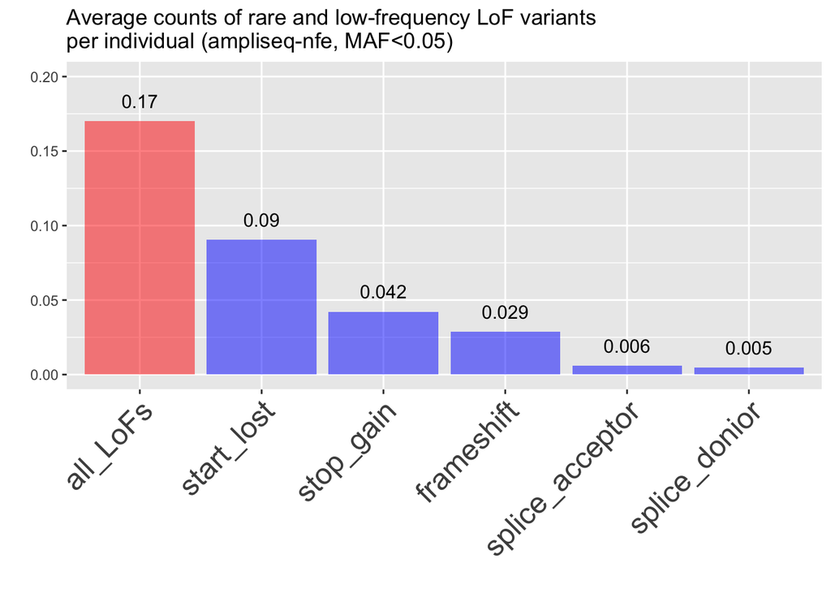

```r
# Order of levels defines order of bars on the plot
lof_summary_counts.df$lof_type <- factor(lof_summary_counts.df$lof_type,
  levels=c("all_LoFs", "start_lost", "stop_gain", "frameshift", "splice_acceptor", "splice_donior"))

# Plot
ggplot(lof_summary_counts.df, aes(lof_type, lof_count)) +
  geom_bar(stat="identity", fill=c("red",rep("blue",5)), alpha=0.5) +
  geom_text(aes(label=round(lof_count,3)), vjust=-1, size=4) +
  labs(x = "", y = "") +
  ylim(0,0.2) +
  theme(axis.text.x = element_text(hjust=1, size=18, angle=45)) +
  ggtitle("Average counts of rare and low-frequency LoF variants\nper individual (ampliseq-nfe, MAF<0.05)")
```

```r
# Clean-up
rm(splice_acceptor_variant, splice_donor_variant, stop_gain, frameshift_variant,
   start_lost, sav.mean, sdv.mean, stogv.mean, stalv.mean, fsv.mean,
   lof.mean, lof_summary_counts.df)
```

## DDM : Deleterious Damaging Missense

missense variants that are both: [ deleterious by SIFT ] AND [ probably_damaging by PolyPhen ]

NB: Not yet excluding known benign/contradicting

```r
missense_all <- grepl( "missense_variant", variants.df$Consequence)
sum(missense_all)
```

```
## [1] 638
```

```r
# Note many NAs: these are when SIFT is irrelevant (e.g. non-coding)
# Note substitution of NAs to FALSE: this is required for combining logical vectors later
# Importantly, the meaning of NAs is equivalent to FALSE in the given context

summary(as.factor(variants.df$SIFT_call))
```

```
##                deleterious deleterious_low_confidence                  tolerated   tolerated_low_confidence                       NA's
##                        226                         11                        336                         25                        711
```

```r
deleterious <- variants.df$SIFT_call == "deleterious"
summary(deleterious)
```

```
##    Mode   FALSE    TRUE    NA's
## logical     372     226     711
```

```r
FALSE -> deleterious[is.na(deleterious)]
summary(deleterious)
```

```
##    Mode   FALSE    TRUE
## logical    1083     226
```

```r
summary(as.factor(variants.df$PolyPhen_call))
```

```
##            benign possibly_damaging probably_damaging              NA's
##               376                92               172               669
```

```r
probably_damaging <- variants.df$PolyPhen_call == "probably_damaging"
summary(probably_damaging)
```

```
##    Mode   FALSE    TRUE    NA's
## logical     468     172     669
```

```r
FALSE -> probably_damaging[is.na(probably_damaging)]
summary(probably_damaging)
```

```
##    Mode   FALSE    TRUE
## logical    1137     172
```

```r
ddm <- deleterious & probably_damaging
sum(ddm)
```

```
## [1] 125
```

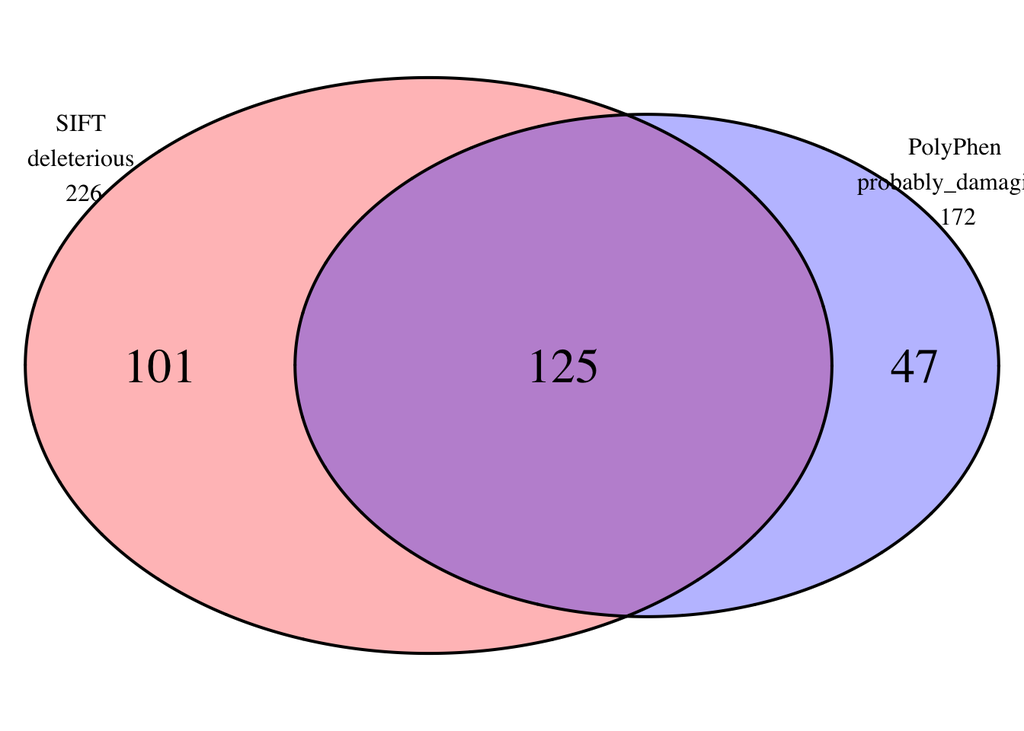

```
## (polygon[GRID.polygon.49], polygon[GRID.polygon.50], polygon[GRID.polygon.51], polygon[GRID.polygon.52], text[GRID.text.53], text[GRID.text.54], text[GRID.text.55], text[GRID.text.56], text[GRID.text.57])
```

```r
# Plot venn diagram of selected variants by types
grid.newpage()
draw.pairwise.venn(
  area1=sum(deleterious),
  area2=sum(probably_damaging),
  cross.area=sum(ddm),
  category=c(
    paste("SIFT\ndeleterious\n", sum(deleterious)),
    paste("PolyPhen\nprobably_damaging\n", sum(probably_damaging))),
  fill=c("red", "blue"),
  alpha = c(0.3, 0.3),
  cex=2)
```

```r
# Clean-up
rm(missense_all, deleterious, probably_damaging)
```